# Syracuse Poverty

Sam Edelstein

9/16/2018

# Poverty in Syracuse

The City of Syracuse was recently cited as one of the top 10 poorest cities in the country by the US Census Bureau. The Census Bureau puts out a yearly survey of a sample of the population called the American Community Survey. They also put out a compiled American Community Survey that combines ACS data from the previous 5 years. The 1 year survey has information from fewer people so it doesn’t get as granular as the 5 year survey, which often allows an analysis down to a census tract or census block group levels rather than only at a city-wide level.

## Percent of people in poverty in Syracuse since 2011 (ACS 1-yr)

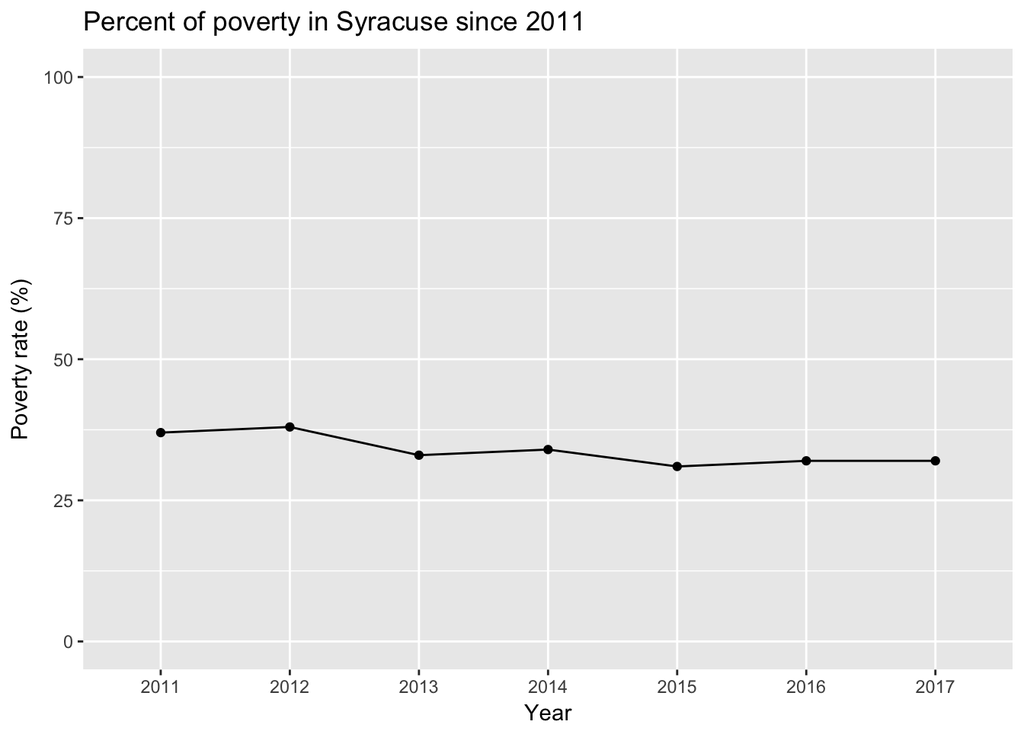

## Poverty by city in 2017

We can also compare against other cities to benchmark. Here we can see that Syracuse has one of the highest poverty rates in the state.

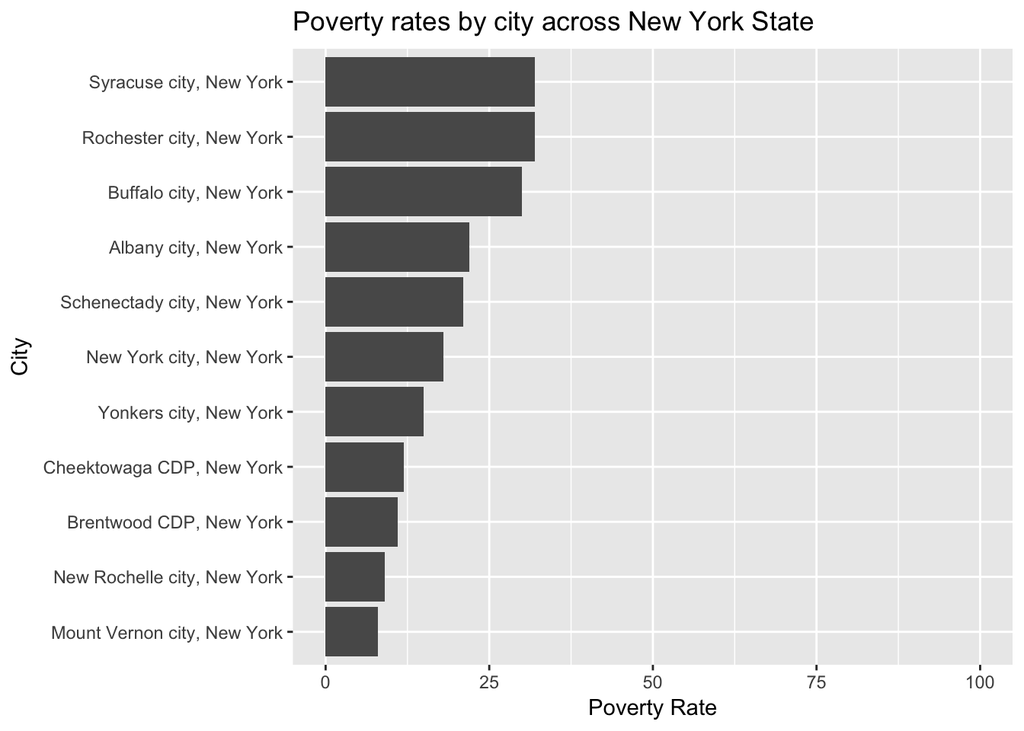

## Public Transportation History

We can also look at specific measures, like how many people take public transportation - or even more detailed - how many people in poverty take public transportation.

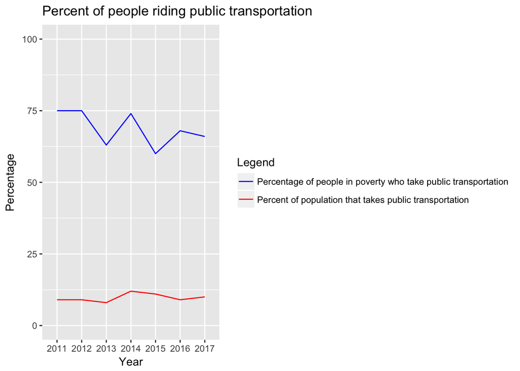

## Public transportation by city

And again we can compare by city

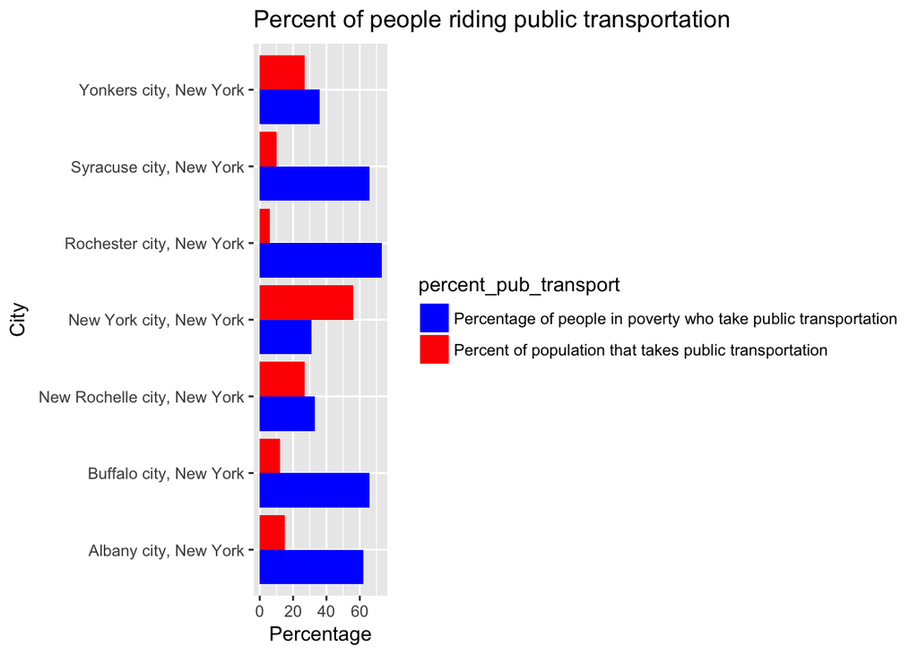

## Map of public transportation ridership

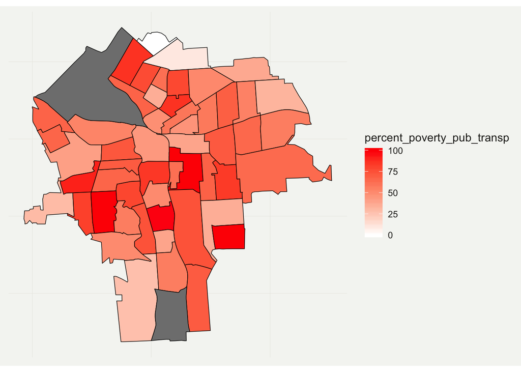

## Percent public transportation overall

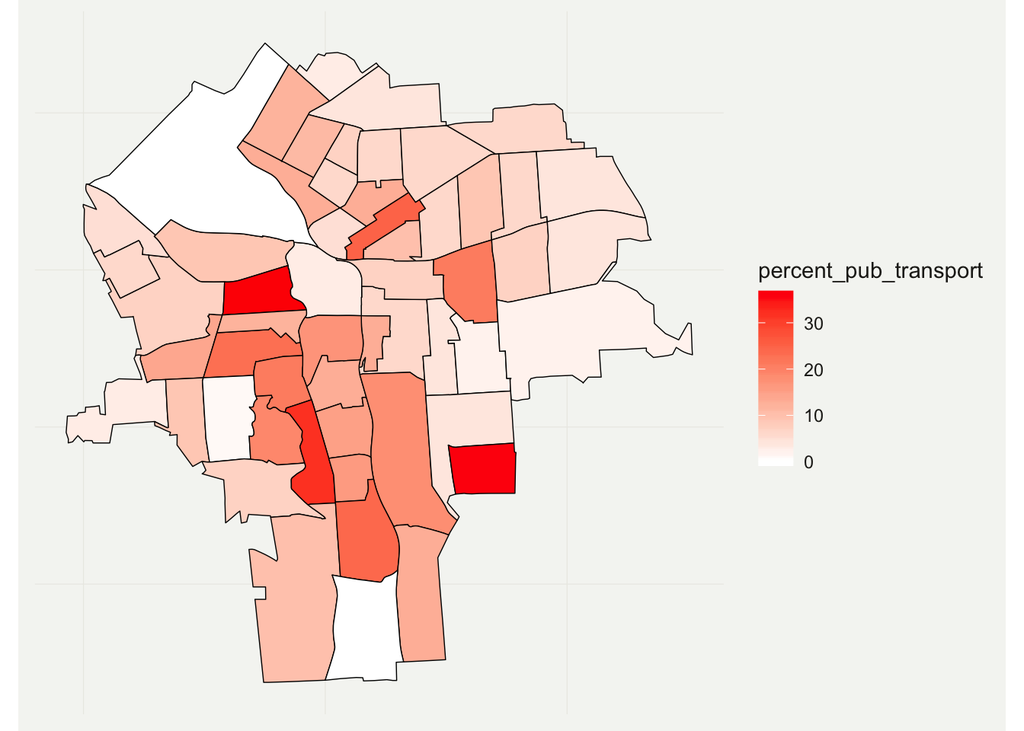

## Percent of people with computer science or math degrees

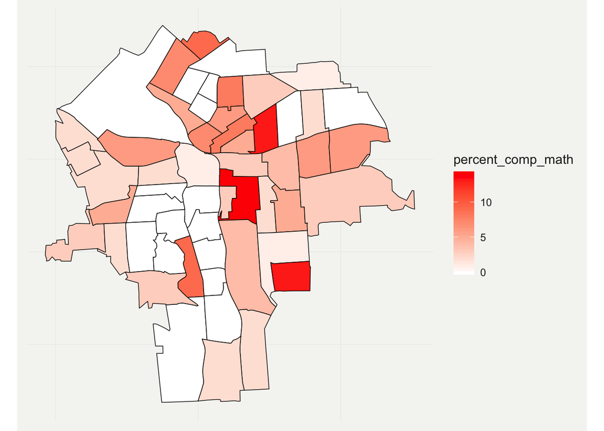

## No schooling by census tract

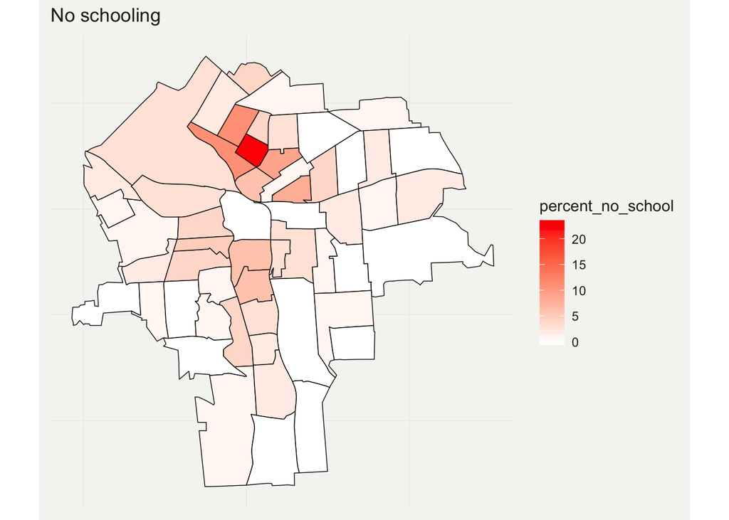

## Less than high school education

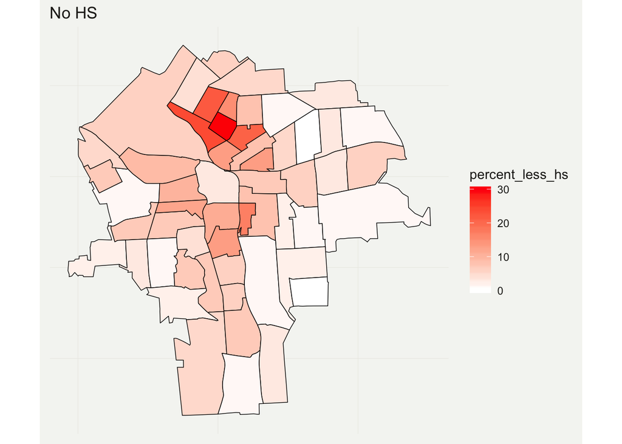

## No hs degree map

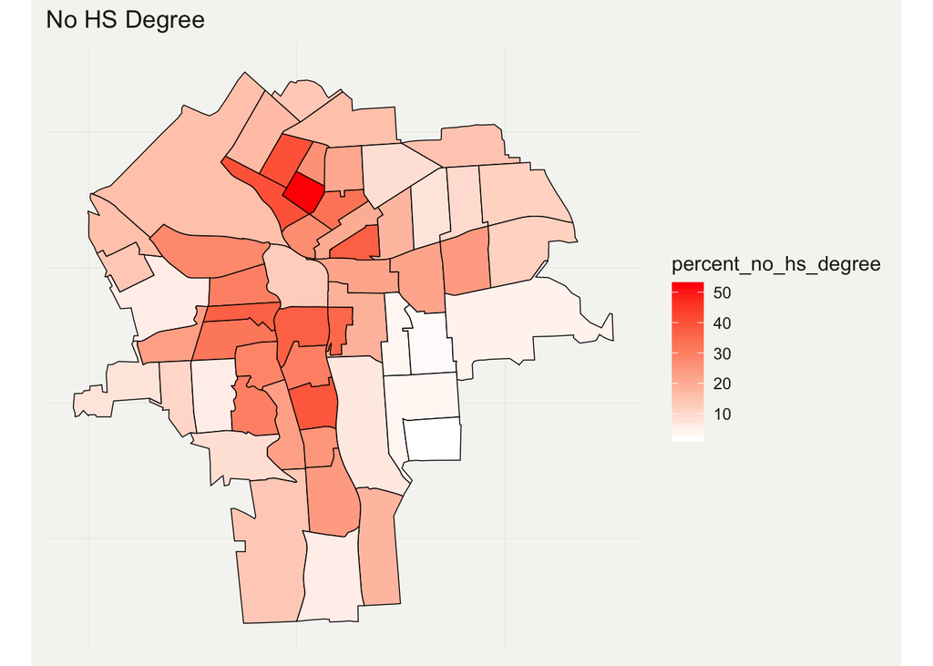